# ASM Chapter 7

code

julia

statistics

asm

ecology

Author

Dr Alun ap Rhisiart

Published

November 12, 2026

# ASM Chapter 7

## 7.2 Fixed-Effects Models

Chapter 7 of Applied Statistical Modelling for Ecologists by Kéry and Kellner focuses on fixed-effects and random-effects models, providing practical examples and guidance for ecological data analysis for one-way ANOVA. Like the last chapter, this features two models, and we will translate each into Julia.

### 7.2.1 Generating the data

As in previous chapters, we drop into R to generate the data so that it matches the examples in the book. However, first, I want to see how it would be done in Julia. The simulated data here represent snout-to-vent (SVL) lengths of 10 smooth snakes from each of five populations.

```julia
using Random, Distributions, DataFrames, Statistics, CategoricalArrays
Random.seed!(72)
nPops = 5
nSample = 10
pop_means = [50, 40, 45, 55, 60]
σ = 5

n = nPops * nSample
ε = rand(Normal(0, σ), n)
pop = repeat(1:5, inner=nSample)
means = repeat(pop_means, inner=nSample)
X = hcat([pop .== i for i in 1:5]...) # This generates a design matrix encoded efficiently as a bit-matrix
y = X * pop_means .+ ε
```

```
50-element Vector{Float64}:
 52.27595066289548
 50.910128150562876
 50.72039409315752
 48.74314029094526
 52.73841423960742
 48.220327771781236
 41.082718975741834
 58.62814329350371
 49.64865438030759
 46.05869170909287
  ⋮
 60.48001527570767
 59.4134099131295
 58.40189626316865
 54.358249830477675
 63.49871501127612
 60.2926800202463
 55.73394840533504
 70.34854639036769
 56.50274401923437
```

Now let’s generate the data in R to match the book’s example. Note in this case that ‘pop’ is treated as a factor (strings), but Turing needs integers, and nSample gets returned as a float, but we need an integer. So I use the values created above instead of `rget` the data from R.

```julia
using RCall, DataFrames

R"""
set.seed(72)
nPops <- 5
nSample <- 10
pop.means <- c(50, 40, 45, 55, 60)
sigma <- 5

n <- nPops * nSample
eps <- rnorm(n, 0, sigma)
pop <- factor(rep(1:5, rep(nSample, nPops)))
means <- rep(pop.means, rep(nSample, nPops))
X <- as.matrix(model.matrix(~ pop - 1))
y <- as.numeric(X %*% as.matrix(pop.means) + eps)
"""
@rget y
```

### 7.2.2 Likelihood analysis

The book shows the code for effects parameterization, but the output for means only. In R pop is a factor. We need to use CategoricalArrays.jl in Julia to handle it similarly.

```julia
using Distributions, GLM, DataFramesMeta

# means parameterisation
df = DataFrame(y=y, pop=categorical(pop))
model = lm(@formula(y ~ -1 + pop), df)
```

```
StatsModels.TableRegressionModel{LinearModel{GLM.LmResp{Vector{Float64}}, GLM.DensePredChol{Float64, LinearAlgebra.CholeskyPivoted{Float64, Matrix{Float64}, Vector{Int64}}}}, Matrix{Float64}}

y ~ 0 + pop

Coefficients:
──────────────────────────────────────────────────────────────────
          Coef.  Std. Error      t  Pr(>|t|)  Lower 95%  Upper 95%
──────────────────────────────────────────────────────────────────
pop: 1  52.4731     1.35859  38.62    <1e-35    49.7368    55.2095
pop: 2  39.3056     1.35859  28.93    <1e-29    36.5692    42.0419
pop: 3  47.0335     1.35859  34.62    <1e-33    44.2972    49.7699
pop: 4  50.611      1.35859  37.25    <1e-34    47.8747    53.3473
pop: 5  62.2568     1.35859  45.82    <1e-38    59.5205    64.9931
──────────────────────────────────────────────────────────────────
```

### 7.2.5 Bayesian analysis with Turing

Heretofore I have not used loops for the likelihood, as it is generally not necessary. In this case I show that you can translate the R code in a way that mirrors the R code more closely. In general you don’t need to do this, but if you plan to use predict() later (eg for a Prior Predictive Check), then that function can struggle with vectorised likelihoods.

```julia
using Turing

@model function fixed_effects(y, pop, nPops)
    # Parameters and Priors
    α ~ filldist(Normal(0, 100), nPops)
    σ ~ truncated(Cauchy(0, 10); lower = 0)

    # Likelihood: Use a for loop to allow predict() to simulate missing data
    for i in eachindex(y)
        y[i] ~ Normal(α[pop[i]], σ)
    end

    # Generated Quantities
    effe2 = α[2] - α[1]
    effe3 = α[3] - α[1]
    effe4 = α[4] - α[1]
    effe5 = α[5] - α[1]

    test1 = (effe2 + effe3) - (effe4 + effe5)
    test2 = effe5 - 2 * effe4

    return (; effe2, effe3, effe4, effe5, test1, test2)
end

model = fixed_effects(y, pop, nPops)
chain_fe = sample(model, NUTS(), MCMCThreads(), 3000, 4; progress=false)
```

```julia
using FlexiChains, MCMCDiagnosticTools

summarystats(chain_fe)
```

```
╭─FlexiSummary (9 statistics) ─────────────────────────────────────────────────╮
│   iter    collapsed                                                          │
│   chain   collapsed                                                          │
│ ↓ stat  = [mean, std, mcse, ess_bulk, ess_tail, rhat, q5, q50, q95]          │
│                                                                              │
│ Parameters (6) ── AbstractPPL.VarName                                        │
│  Float64  α[1], α[2], α[3], α[4], α[5], σ                                    │
│                                                                              │
│ Extras (14)                                                                  │
│  Float64  n_steps, is_accept, acceptance_rate, log_density                   │
│           hamiltonian_energy, hamiltonian_energy_error                       │
│           max_hamiltonian_energy_error, tree_depth, numerical_error          │
│           step_size, nom_step_size, logprior, loglikelihood, logjoint        │
│                                                                              │
│ Summary                                                                      │
│  param  mean     std     mcse    …  rhat    q5       q50      q95            │
│  α[1]   52.4653  1.3757  0.0106     1.0001  50.2193  52.4765  54.7142        │
│  α[2]   39.2823  1.3876  0.0109     1.0005  36.9826  39.2826  41.5383        │
│  α[3]   47.0154  1.4212  0.0114     1.0001  44.6851  47.0138  49.3357        │
│  α[4]   50.5935  1.3976  0.0111     1.0011  48.3207  50.5883  52.8892        │
│  α[5]   62.2427  1.4252  0.0103  …  1.0000  59.9029  62.2376  64.5613        │
│  σ      4.4040   0.4738  0.0040     0.9999  3.7016   4.3626   5.2485         │
╰──────────────────────────────────────────────────────────────────────────────╯
```

Unlike the Stan example, here we have ’return’ed the generated quantities, so they are available in the MCMC chain, but they are not included in the above summary, because they are not calculated during the MCMC sampling itself. Remember you can use `:=` instead of `=` plus `return` to calculate during the run if it is not too expensive. Since I need to get these generated quantities for the random-effects model too, I’ll put it in a reusable function.

```julia
using DataFrames
using Statistics

function summarize_generated_quantities(model, chain)
    gen_quants = generated_quantities(model, chain)
    df_samples = DataFrame(vec(gen_quants))
    summary_table = DataFrame(
        Parameter = names(df_samples),
        Mean = mean.(eachcol(df_samples)),
        SD = std.(eachcol(df_samples)),
        Lower_2_5 = [quantile(col, 0.025) for col in eachcol(df_samples)],
        Median = [quantile(col, 0.5) for col in eachcol(df_samples)],
        Upper_97_5 = [quantile(col, 0.975) for col in eachcol(df_samples)]
    )
    return summary_table
end
summarize_generated_quantities(model, chain_fe)
```

6×6 DataFrame

| Row | Parameter String | Mean Float64 | SD Float64 | Lower_2_5 Float64 | Median Float64 | Upper_97_5 Float64 |
| --- | --- | --- | --- | --- | --- | --- |
| 1 | effe2 | -13.183 | 1.96022 | -17.042 | -13.171 | -9.29035 |
| 2 | effe3 | -5.44992 | 1.99998 | -9.3812 | -5.45576 | -1.51831 |
| 3 | effe4 | -1.87183 | 1.9575 | -5.76281 | -1.87089 | 1.93712 |
| 4 | effe5 | 9.77738 | 1.96842 | 5.86683 | 9.77106 | 13.6193 |
| 5 | test1 | -26.5385 | 2.81521 | -32.0601 | -26.571 | -21.0364 |
| 6 | test2 | 13.521 | 3.42223 | 6.77239 | 13.5299 | 20.3111 |

### 7.2.6 DIY Maximum Likelihood Estimates

There are a couple of differences to keep in mind in using Julia rather than R.

- Matrix Multiplication: In R, you would use `%*%` to multiply $X$ and α. In Julia, the standard `*` operator performs true matrix multiplication automatically when the left operand is a Matrix and the right is a Vector.
- Preventing Domain Errors: The line `if σ <= 0.0 return Inf end` is a critical Julia optimization pattern. Unlike R’s `optim()` which can sometimes suppress internal warnings, Distributions.jl will throw a hard error if you try to instantiate a Normal distribution with a negative standard deviation. Returning Inf cleanly tells Optim.jl to move away from that parameter space.
- Anonymous Functions for Optimizers: R’s optim allows you to pass additional data arguments (like y and X) via the … argument. Optim.jl strictly expects a function of a single variable (the parameter vector). The syntax `p -> NLL(p, y, X)` creates a fast, on-the-fly closure that satisfies this requirement.

```julia
using Distributions
using Optim
using Statistics

# Define the Negative Log-Likelihood (NLL) function
function NLL(param, y, X)
    α = param[1:5]
    σ = param[6]

    # The optimizer will sometimes test negative values for sigma.
    # Returning Inf acts as a hard boundary to prevent domain errors.
    if σ <= 0.0
        return Inf
    end

    # Matrix multiplication: X (n x 5) * alpha (5 x 1) = mu (n x 1)
    μ = X * α

    # Calculate the negative sum of the log-likelihoods
    return -sum(logpdf.(Normal.(μ, σ), y))
end

# Build the design matrix (X)
# This creates an n x 5 matrix of zeros, then places a 1.0 in the column
# corresponding to the population index for each observation.
n = length(y)
X = zeros(Float64, n, 5)
for i in 1:n
    X[i, pop[i]] = 1.0
end

# Set initial values for the optimizer
# A good starting point is the global mean of y for the alphas, and the global standard deviation for sigma
init_param = [fill(mean(y), 5); std(y)]

# Run the optimizer
# We use an anonymous function (p -> NLL(p, y, X)) to pass the data along with the parameters
result = optimize(p -> NLL(p, y, X), init_param, NelderMead())

# Extract the MLE estimates
mle_estimates = Optim.minimizer(result)

round.(mle_estimates, digits=3)
```

```
6-element Vector{Float64}:
 52.473
 39.305
 47.033
 50.611
 62.257
  4.076
```

## 7.3 Random Effects

The main point of this chapter is highlighting the difference between fixed effects and random effects models in the context of hierarchical data. So let’s get into it.

- Fixed effects (β parameters): These are the parameters we treat as constant across the population (or the specific contrasts we care about). We put priors directly on them. They represent the “average” or “overall” effect (e.g., global intercept, slope of a covariate like year or habitat).
- Random effects (u or α parameters): These are group-specific deviations (e.g., site-specific intercepts, year-specific intercepts). We model them as coming from a common probability distribution (usually Normal(0, σ_group)), with hyperparameters (mean μ_group, usually 0 after centering, and variance σ_group²) that are themselves estimated. This induces partial pooling / shrinkage.

This is the key Bayesian hierarchical insight: random effects are parameters with their own priors that are estimated from the data, allowing us to borrow strength across groups while quantifying group-level variation. Random effects ‘soak up’ variance that would otherwise inflate the residual error, leading to more accurate estimates of both group-level and overall effects. Fixed effects, on the other hand, are treated as constant across groups and capture the overall mean trends in the data.

In code, we can see the difference in the parameters.

Fixed effects will be coded like `β ~ Normal(0, 10)` while random effects will be coded like `α[group] ~ Normal(0, σ_group)`, with a hyperprior on the group-level standard deviation, e.g., `σ_group ~ Exponential(1)`. The parameters of the distribution are not fixed quantities, they are defined on a separate line of code and shared.

### 7.3.1 Data generation

In Julia we would create the data as follows.

```julia
using Distributions, CategoricalArrays

nPops = 10
nSample = 12
n = nPops * nSample
pop_grand_mean = 50
pop_sd = 3
pop_means = rand(Normal(pop_grand_mean, pop_sd), nPops)
σ = 5
ε = rand(Normal(0, σ), n)
pop = repeat(1:nPops, inner=nSample)
Xmat = hcat([pop .== i for i in 1:nPops]...)

y = Xmat * pop_means + ε
```

The R code to generate the data is:

```julia
R"""
set.seed(73)
nPops <- 10
nSample <- 12
n <- nPops * nSample
pop.grand.mean <- 50
pop.sd <- 3
pop_means <- rnorm(n=nPops, mean=pop.grand.mean, sd=pop.sd)
sigma <- 5
eps <- rnorm(n=n, mean=0, sd=sigma)
pop <- factor(rep(1:nPops, rep(nSample, nPops)))
Xmat <- as.matrix(model.matrix(~ pop -1))
y <- as.numeric(Xmat %*% as.matrix(pop_means) + eps)
"""
@rget y pop_means
```

### 7.3.2 Likelihood analysis with canned functions

The julia equivalent of lme4 is MixedModels.jl. See https://juliastats.org/MixedModels.jl/dev/for_r_users/ for a comparison with R. Note that in each case I convert pop to categorical form MLE, but keep it as integers for Turing.

```julia
using MixedModels, DataFrames

df = DataFrame(y=y, pop=categorical(pop))
form = @formula(y ~ 1 + (1 | pop))
model = fit(MixedModel,form, df)
print(model)
```

```
Linear mixed model fit by maximum likelihood
 y ~ 1 + (1 | pop)
   logLik   -2 logLik     AIC       AICc        BIC
  -377.4275   754.8551   760.8551   761.0620   769.2176

Variance components:
            Column   Variance Std.Dev.
pop      (Intercept)   7.17234 2.67812
Residual              28.09962 5.30091
 Number of obs: 120; levels of grouping factors: 10

  Fixed-effects parameters:
─────────────────────────────────────────────────
               Coef.  Std. Error      z  Pr(>|z|)
─────────────────────────────────────────────────
(Intercept)  51.9202    0.975396  53.23    <1e-99
─────────────────────────────────────────────────
```

This is almost exactly matching glmmTMB output. We can also try REML.

```julia
model_reml = fit(MixedModel, form, df, REML=true)
print(model_reml)
```

```
Linear mixed model fit by REML
 y ~ 1 + (1 | pop)
 REML criterion at convergence: 753.0152786269679

Variance components:
            Column   Variance Std.Dev.
pop      (Intercept)   8.22945 2.86870
Residual              28.09962 5.30091
 Number of obs: 120; levels of grouping factors: 10

  Fixed-effects parameters:
─────────────────────────────────────────────────
               Coef.  Std. Error      z  Pr(>|z|)
─────────────────────────────────────────────────
(Intercept)  51.9202     1.02816  50.50    <1e-99
─────────────────────────────────────────────────
```

### 7.3.5 Bayesian analysis with Turing

In the Stan code it uses truncated Cauchy for pop_means, but that causes issues with ForwardDiff in Julia, so we use a plain Normal instead. Since y is all positive, we get the same result. On first running I got a few divergent transitions, but changing the target acceptance rate in NUTS helped.

Because `effe` is a vector in Stan rather than separate scalars, returning `NamedTuple(Symbol("effe[$i]") => effe[i] for i in 1:nPops)` unpacks effe[i] through effe[nPops] into individual scalar fields. The generated_quantities output then drops straight into the FlexiChain conversion code from the fixed-effects model without modification.

```julia
@model function random_effects(y, pop, nPops)
    # Hyperpriors and variance components (constant bounds are safe for ForwardDiff)
    pop_grand_mean ~ truncated(Normal(0, 100), 0, Inf)
    pop_sd ~ truncated(Cauchy(0, 10), 0, Inf)
    residual_sd ~ truncated(Cauchy(0, 10), 0, Inf)

    # Random population means (plain Normal avoids the ForwardDiff Inf-bound NaN bug)
    pop_mean ~ filldist(Normal(pop_grand_mean, pop_sd), nPops)

    # Likelihood
    for i in eachindex(y)
        y[i] ~ Normal(pop_mean[pop[i]], residual_sd)
    end

    # Generated quantities
    effe = pop_mean .- pop_grand_mean
    return NamedTuple(Symbol("effe[$i]") => effe[i] for i in 1:nPops)
end

random_model = random_effects(y, pop, nPops)
chains_re = sample(random_model, NUTS(0.95), MCMCThreads(), 3000, 4; progress=false)
```

```julia
summarystats(chains_re)
```

```
╭─FlexiSummary (9 statistics) ─────────────────────────────────────────────────╮
│   iter    collapsed                                                          │
│   chain   collapsed                                                          │
│ ↓ stat  = [mean, std, mcse, ess_bulk, ess_tail, rhat, q5, q50, q95]          │
│                                                                              │
│ Parameters (13) ── AbstractPPL.VarName                                       │
│  Float64  pop_grand_mean, pop_sd, residual_sd, pop_mean[1], pop_mean[2]      │
│           pop_mean[3], pop_mean[4], pop_mean[5], pop_mean[6], pop_mean[7]    │
│           pop_mean[8], pop_mean[9], pop_mean[10]                             │
│                                                                              │
│ Extras (14)                                                                  │
│  Float64  n_steps, is_accept, acceptance_rate, log_density                   │
│           hamiltonian_energy, hamiltonian_energy_error                       │
│           max_hamiltonian_energy_error, tree_depth, numerical_error          │
│           step_size, nom_step_size, logprior, loglikelihood, logjoint        │
│                                                                              │
│ Summary                                                                      │
│  param         mean     std     …  rhat    q5       q50      q95             │
│  pop_grand_m…  51.9257  1.2440     1.0006  49.9230  51.9244  53.9345         │
│  pop_sd        3.3086   1.1199     1.0006  1.8590   3.1252   5.3757          │
│  residual_sd   5.3589   0.3664     1.0002  4.7882   5.3368   5.9936          │
│  pop_mean[1]   50.7155  1.3806     1.0010  48.4618  50.7340  52.9363         │
│  pop_mean[2]   51.5980  1.4027  …  1.0002  49.3132  51.6026  53.9419         │
│  pop_mean[3]   52.6864  1.3693     1.0003  50.4281  52.6768  54.9257         │
│  pop_mean[4]   52.9438  1.3841     1.0004  50.6719  52.9470  55.2280         │
│  pop_mean[5]   46.7120  1.5504     1.0000  44.1917  46.7043  49.2766         │
│  pop_mean[6]   49.3286  1.4319     1.0002  46.9748  49.3364  51.6722         │
│  pop_mean[7]   52.6362  1.3947  …  0.9999  50.3599  52.6358  54.9185         │
│  pop_mean[8]   55.8662  1.5026     1.0002  53.4244  55.8448  58.3751         │
│  pop_mean[9]   54.2050  1.4616     1.0001  51.7916  54.2015  56.6070         │
│  pop_mean[10]  52.5637  1.4113     1.0004  50.2790  52.5600  54.9147         │
╰──────────────────────────────────────────────────────────────────────────────╯
```

And the generated effects

```julia
summarize_generated_quantities(random_model, chains_re)
```

10×6 DataFrame

| Row | Parameter String | Mean Float64 | SD Float64 | Lower_2_5 Float64 | Median Float64 | Upper_97_5 Float64 |
| --- | --- | --- | --- | --- | --- | --- |
| 1 | effe[1] | -1.21021 | 1.70828 | -4.57462 | -1.18573 | 2.16931 |
| 2 | effe[2] | -0.32773 | 1.72983 | -3.77524 | -0.339097 | 3.15131 |
| 3 | effe[3] | 0.760731 | 1.70721 | -2.56732 | 0.738342 | 4.18286 |
| 4 | effe[4] | 1.01812 | 1.716 | -2.33395 | 0.995783 | 4.42358 |
| 5 | effe[5] | -5.21369 | 1.85396 | -9.05604 | -5.1458 | -1.72432 |
| 6 | effe[6] | -2.59708 | 1.76351 | -6.11675 | -2.58315 | 0.754402 |
| 7 | effe[7] | 0.710495 | 1.72332 | -2.67129 | 0.715113 | 4.1403 |
| 8 | effe[8] | 3.94055 | 1.82411 | 0.563011 | 3.89661 | 7.73723 |
| 9 | effe[9] | 2.27929 | 1.79523 | -1.23842 | 2.25698 | 5.89707 |
| 10 | effe[10] | 0.638057 | 1.75207 | -2.75538 | 0.619922 | 4.10001 |

Next we can look at Figure 7.4, the posterior distribution of the among-population SD of SVL. This is strongly right-skewed due to the small number of populations.

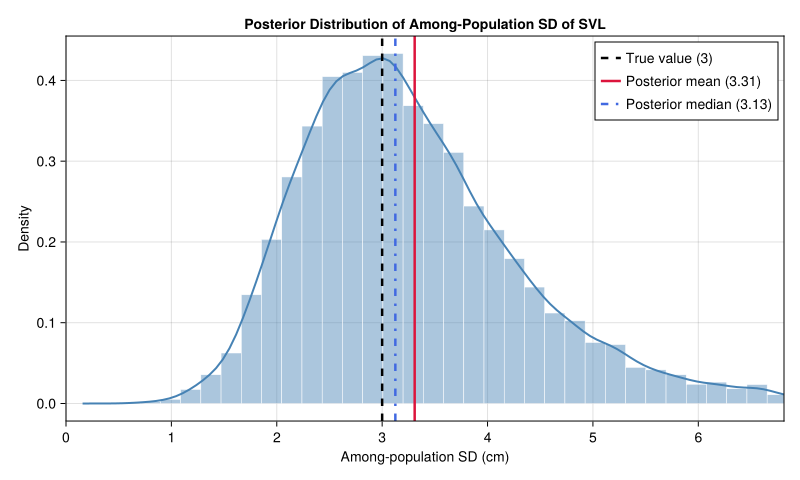

```julia
using CairoMakie

# Extract posterior draws from the random-effects FlexiChain
# (Named pop_sd_post so it doesn't shadow your true simulation variable `pop_sd`)
pop_sd_post = vec(chains_re[@varname(pop_sd)])

post_mean   = mean(pop_sd_post)
post_median = median(pop_sd_post)

fig74 = Figure(size = (800, 480))
ax74 = Axis(fig74[1, 1],
    title = "Posterior Distribution of Among-Population SD of SVL",
    xlabel = "Among-population SD (cm)",
    ylabel = "Density"
)

# Histogram + smooth density curve
hist!(ax74, pop_sd_post,
    bins = 60,
    normalization = :pdf,
    color = (:steelblue, 0.45),
    strokecolor = :white,
    strokewidth = 0.5
)
CairoMakie.density!(ax74, pop_sd_post, color = (:steelblue, 0.0), strokecolor = :steelblue, strokewidth = 2)

# Reference lines comparing Truth, Posterior summaries, and MLE
vlines!(ax74, [pop_sd],    color = :black,     linestyle = :dash,    linewidth = 2.5, label = "True value ($(pop_sd))")
vlines!(ax74, [post_mean], color = :crimson,   linestyle = :solid,   linewidth = 2.5, label = "Posterior mean ($(round(post_mean, digits = 2)))")
vlines!(ax74, [post_median], color = :royalblue, linestyle = :dashdot, linewidth = 2.5, label = "Posterior median ($(round(post_median, digits = 2)))")

# Trim the extreme upper tail so the bulk of the distribution is readable
xlims!(ax74, 0, quantile(pop_sd_post, 0.99))
axislegend(ax74, position = :rt)

fig74
```

Figure 7.5 is a comparison of fixed- and random-effects estimates for the same dataset with the true population means. Note that the number of populations was changed from 5 to 10 in the code, but nPops was left at 10 from the code above. In the book they show comparisons of fixed and random for all 10 populations. Since I want the fixed-effects model output to match the book I have left it at 5. The code in the github repository shows that before generating the figure the fixed-effects model is run on the second set of data.

````markdown
```{r}
cat(file = "model73.3fix.txt", "
model {
# Priors (and also some derived quantities)
for (i in 1:nPops){
  # Prior for population means: no estimated hyperparameters now !
  pop.mean[i] ~ dnorm(0, 0.0001)
}
residual.sd ~ dunif(0, 10) # Prior for residual sd
residual.tau <- pow(residual.sd, -2)

# 'Likelihood'
for (i in 1:n) {
  y[i] ~ dnorm(mu[i], residual.tau)
  mu[i] <- pop.mean[pop[i]]
}
}
")
```
````

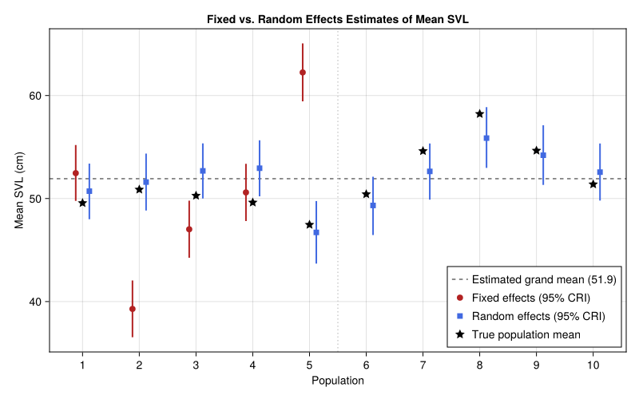

```julia
# Extract posterior means and 95% CRIs for each population
fe_means = [mean(vec(chain_fe[@varname(α[i])])) for i in 1:5]
fe_low   = [quantile(vec(chain_fe[@varname(α[i])]), 0.025) for i in 1:5]
fe_high  = [quantile(vec(chain_fe[@varname(α[i])]), 0.975) for i in 1:5]

re_means = [mean(vec(chains_re[@varname(pop_mean[i])])) for i in 1:nPops]
re_low   = [quantile(vec(chains_re[@varname(pop_mean[i])]), 0.025) for i in 1:nPops]
re_high  = [quantile(vec(chains_re[@varname(pop_mean[i])]), 0.975) for i in 1:nPops]

grand_mean_est = mean(vec(chains_re[@varname(pop_grand_mean)]))

# Build the comparison plot
x = 1:nPops
x_fe = 1:length(fe_means) # 1:5 for the fixed-effects subset
offset = 0.12

fig75 = Figure(size = (800, 500))
ax75 = Axis(fig75[1, 1],
    title = "Fixed vs. Random Effects Estimates of Mean SVL",
    xlabel = "Population",
    ylabel = "Mean SVL (cm)",
    xticks = (x, string.(x))
)

# Grand mean reference line
hlines!(ax75, [grand_mean_est],
    color = :gray40,
    linestyle = :dash,
    linewidth = 1.5,
    label = "Estimated grand mean ($(round(grand_mean_est, digits = 1)))"
)

# Optional: subtle vertical divider showing where the 5-population fixed-effects model ends
vlines!(ax75, [5.5], color = :gray80, linestyle = :dot, linewidth = 1.5)

# Fixed-effects estimates (populations 1–5 only)
rangebars!(ax75, x_fe .- offset, fe_low, fe_high, color = :firebrick, linewidth = 2)
scatter!(ax75, x_fe .- offset, fe_means,
    color = :firebrick,
    marker = :circle,
    markersize = 11,
    label = "Fixed effects (95% CRI)"
)

# Random-effects estimates (all 10 populations)
rangebars!(ax75, x .+ offset, re_low, re_high, color = :royalblue, linewidth = 2)
scatter!(ax75, x .+ offset, re_means,
    color = :royalblue,
    marker = :rect,
    markersize = 11,
    label = "Random effects (95% CRI)"
)

# True simulated population means (all 10 populations)
scatter!(ax75, x, pop_means,
    color = :black,
    marker = :star5,
    markersize = 14,
    label = "True population mean"
)

axislegend(ax75, position = :rb)

fig75
```

This *doesn’t* match the figure in the book that well, but I think that is because when they generated the code for figure 7.5 they reran the fixed effect model for 10 populations (since they clearly show them), and the means are not the same as what is published. The means for the five populations in the fixed-effects model were for data generated with a different seed than the one used for the 10-population model, so it is expected that they won’t match well.

I’ll leave it as it is, since the main point is showing how to make such a graph in Julia, and the output from each model separately does match what is shown in the book pretty well.

### 7.3.6 DIY maximum likelihood estimates

We finish with the MLE estimate for random effects. There are some significant differences here.

#### quadgk Return Signature

Unlike R’s integrate(…)$value, QuadGK.quadgk returns a 2-tuple (integral, estimated_error). Unpacking with `L, _ = quadgk(...)` grabs the integral directly.

#### Extracting the Hessian

Wrapping the objective with `TwiceDifferentiable(NLL, inits)` instructs Optim.jl to use finite differences for both the BFGS gradient steps and Optim.hessian!(td, mle_raw) at the converged solution, matching R’s optim(…, hessian = TRUE) behavior.

```julia
using QuadGK
using LinearAlgebra

function NLL(pars)
    pop_grand_mean = pars[1]
    pop_sd = exp(pars[2])
    sigma = exp(pars[3])

    LL = 0.0
    for i in 1:nPops
        # Subset data to population i
        ysub = y[pop .== i]

        # Numerically integrate out the random population effect r ~ Normal(0, pop_sd)
        L, _ = quadgk(-Inf, Inf) do r
            tot = 1.0
            for yj in ysub
                tot *= pdf(Normal(pop_grand_mean + r, sigma), yj)
            end
            tot *= pdf(Normal(0.0, pop_sd), r)
            return tot
        end

        # Guard against log(<= 0) during BFGS line searches
        if L <= 0.0
            return Inf
        end
        LL += log(L)
    end

    return -LL
end

# Minimize NLL using BFGS (matching R's optim defaults)
inits = [mean(y), 0.0, log(std(y))]
td = TwiceDifferentiable(NLL, inits)
out73_6 = optimize(td, inits, BFGS())

# Extract MLEs, Hessian, SEs, and 95% CIs (replicating ASMbook::get_MLE)
mle_raw = Optim.minimizer(out73_6)
H = Optim.hessian!(td, mle_raw)
se = sqrt.(diag(inv(H)))

mle_table = DataFrame(
    Parameter = ["pop.grand.mean", "log(pop.sd)", "log(residual.sd)"],
    MLE = round.(mle_raw, digits = 4),
    SE = round.(se, digits = 4),
    LCL = round.(mle_raw .- 1.96 .* se, digits = 4),
    UCL = round.(mle_raw .+ 1.96 .* se, digits = 4)
)
display(mle_table)
```

3×5 DataFrame

| Row | Parameter String | MLE Float64 | SE Float64 | LCL Float64 | UCL Float64 |
| --- | --- | --- | --- | --- | --- |
| 1 | pop.grand.mean | 51.9202 | 0.9754 | 50.0084 | 53.832 |
| 2 | log(pop.sd) | 0.9851 | 0.2974 | 0.4022 | 1.5681 |
| 3 | log(residual.sd) | 1.6679 | 0.0674 | 1.5357 | 1.8 |

Back-transform the SDs to match diy_est

```julia
diy_est = [mle_raw[1], exp(mle_raw[2]), exp(mle_raw[3])]
println("diy_est: ", round.(diy_est, digits = 4))
```

```
diy_est: [51.9202, 2.6781, 5.3009]
```

This all matches the R output pretty closely.

## Summary

I normally do a performance comparison, but this is a long chapter developing each model twice, once for fixed and once for random effects. So I think I will skip that part here.